# Prediction Assignment Writeup

Roberto Feraboli

31/8/2020

# Background

Using devices such as Jawbone Up, Nike FuelBand, and Fitbit it is now possible to collect a large amount of data about personal activity relatively inexpensively. These type of devices are part of the quantified self movement – a group of enthusiasts who take measurements about themselves regularly to improve their health, to find patterns in their behavior, or because they are tech geeks. One thing that people regularly do is quantify how much of a particular activity they do, but they rarely quantify how well they do it. The goal of the project is to predict the manner in which they did the exercise. This is the “classe” variable in the training set.

# Executive summary

I will perform the following task: 1.Load the data 2.Cleaning the dataset by NA and irrelevant variables in order to reduce the predictors 3.Data slicing for building the training and test data set 4.Apply the following machine learning algorithm:Prediction Tree,Random Forest,Boosting to the training set 5.Evaluate on the test set

# 1.Load the data

```r
library(caret)
```

```r
library(rpart)
library(rpart.plot)
library(rattle)
library(randomForest)
library(knitr)
setwd("C:/Users/lenovo/Desktop/COURSERA/DATA SCIENCE-COURSERA/MODULE 8 - Practical Machine Learning/FINAL ASSIGNMENT")
training<- read.csv("pml-training.csv", sep=",",na.strings=c("NA","#DIV/0!", ""))
str(training)
```

```
## 'data.frame':    19622 obs. of  160 variables:
##  $ X                       : int  1 2 3 4 5 6 7 8 9 10 ...
##  $ user_name               : chr  "carlitos" "carlitos" "carlitos" "carlitos" ...
##  $ raw_timestamp_part_1    : int  1323084231 1323084231 1323084231 1323084232 1323084232 1323084232 1323084232 1323084232 1323084232 1323084232 ...
##  $ raw_timestamp_part_2    : int  788290 808298 820366 120339 196328 304277 368296 440390 484323 484434 ...
##  $ cvtd_timestamp          : chr  "05/12/2011 11:23" "05/12/2011 11:23" "05/12/2011 11:23" "05/12/2011 11:23" ...
##  $ new_window              : chr  "no" "no" "no" "no" ...
##  $ num_window              : int  11 11 11 12 12 12 12 12 12 12 ...
##  $ roll_belt               : num  1.41 1.41 1.42 1.48 1.48 1.45 1.42 1.42 1.43 1.45 ...
##  $ pitch_belt              : num  8.07 8.07 8.07 8.05 8.07 8.06 8.09 8.13 8.16 8.17 ...
##  $ yaw_belt                : num  -94.4 -94.4 -94.4 -94.4 -94.4 -94.4 -94.4 -94.4 -94.4 -94.4 ...
##  $ total_accel_belt        : int  3 3 3 3 3 3 3 3 3 3 ...
##  $ kurtosis_roll_belt      : num  NA NA NA NA NA NA NA NA NA NA ...
##  $ kurtosis_picth_belt     : num  NA NA NA NA NA NA NA NA NA NA ...
##  $ kurtosis_yaw_belt       : logi  NA NA NA NA NA NA ...
```

[output cut: 86 more lines]

```r
training$classe<-as.factor(training$classe)
testing<- read.csv("pml-testing.csv", sep=",",na.strings=c("NA","#DIV/0!", ""))
str(testing)
```

```
## 'data.frame':    20 obs. of  160 variables:
##  $ X                       : int  1 2 3 4 5 6 7 8 9 10 ...
##  $ user_name               : chr  "pedro" "jeremy" "jeremy" "adelmo" ...
##  $ raw_timestamp_part_1    : int  1323095002 1322673067 1322673075 1322832789 1322489635 1322673149 1322673128 1322673076 1323084240 1322837822 ...
##  $ raw_timestamp_part_2    : int  868349 778725 342967 560311 814776 510661 766645 54671 916313 384285 ...
##  $ cvtd_timestamp          : chr  "05/12/2011 14:23" "30/11/2011 17:11" "30/11/2011 17:11" "02/12/2011 13:33" ...
##  $ new_window              : chr  "no" "no" "no" "no" ...
##  $ num_window              : int  74 431 439 194 235 504 485 440 323 664 ...
##  $ roll_belt               : num  123 1.02 0.87 125 1.35 -5.92 1.2 0.43 0.93 114 ...
##  $ pitch_belt              : num  27 4.87 1.82 -41.6 3.33 1.59 4.44 4.15 6.72 22.4 ...
##  $ yaw_belt                : num  -4.75 -88.9 -88.5 162 -88.6 -87.7 -87.3 -88.5 -93.7 -13.1 ...
##  $ total_accel_belt        : int  20 4 5 17 3 4 4 4 4 18 ...
##  $ kurtosis_roll_belt      : logi  NA NA NA NA NA NA ...
##  $ kurtosis_picth_belt     : logi  NA NA NA NA NA NA ...
##  $ kurtosis_yaw_belt       : logi  NA NA NA NA NA NA ...
```

[output cut: 86 more lines]

# 2.Clean the dataset by NA and irrelevant variables

```r
training<-training[,colSums(is.na(training))==0]
training<-training[,-c(1:7)]
testing<-testing[,colSums(is.na(testing))==0]
testing<-testing[,-c(1:7)]
```

# 3.Data Slicing

```r
library(kernlab)
inTrain <- createDataPartition(y=training$classe,p=0.60, list=FALSE)
sub_training <- training[inTrain,]
sub_testing <-  training[-inTrain,]
```

# 5.ML Prediction tree

```r
mod_rpart <- train(classe ~ .,method="rpart",data=sub_training)
print(mod_rpart$finalModel)
```

```
## n= 11776
##
## node), split, n, loss, yval, (yprob)
##       * denotes terminal node
##
##  1) root 11776 8428 A (0.28 0.19 0.17 0.16 0.18)
##    2) roll_belt< 130.5 10780 7440 A (0.31 0.21 0.19 0.18 0.11)
##      4) pitch_forearm< -34 947    6 A (0.99 0.0063 0 0 0) *
##      5) pitch_forearm>=-34 9833 7434 A (0.24 0.23 0.21 0.2 0.12)
##       10) magnet_dumbbell_y< 435.5 8287 5943 A (0.28 0.18 0.24 0.19 0.11)
##         20) roll_forearm< 121.5 5142 3036 A (0.41 0.18 0.18 0.17 0.058) *
##         21) roll_forearm>=121.5 3145 2103 C (0.076 0.19 0.33 0.22 0.19) *
##       11) magnet_dumbbell_y>=435.5 1546  758 B (0.036 0.51 0.041 0.22 0.19) *
##    3) roll_belt>=130.5 996    8 E (0.008 0 0 0 0.99) *
```

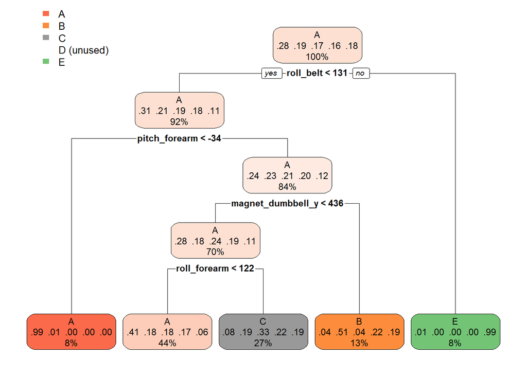

```r
rpart.plot(mod_rpart$finalModel)
```

```r
prediction_rpart<-predict(mod_rpart,newdata=sub_testing)
sub_testing$classe<-as.factor(sub_testing$classe)
confusionMatrix(prediction_rpart,sub_testing$classe)
```

```
## Confusion Matrix and Statistics
##
##           Reference
## Prediction    A    B    C    D    E
##          A 2005  631  632  530  218
##          B   44  519   49  238  203
##          C  177  368  687  518  378
##          D    0    0    0    0    0
##          E    6    0    0    0  643
##
## Overall Statistics
##
##                Accuracy : 0.4912
##                  95% CI : (0.4801, 0.5023)
##     No Information Rate : 0.2845
##     P-Value [Acc > NIR] : < 2.2e-16
##
##                   Kappa : 0.3357
##
##  Mcnemar's Test P-Value : NA
##
## Statistics by Class:
##
##                      Class: A Class: B Class: C Class: D Class: E
## Sensitivity            0.8983  0.34190  0.50219   0.0000  0.44591
## Specificity            0.6418  0.91561  0.77755   1.0000  0.99906
## Pos Pred Value         0.4993  0.49288  0.32284      NaN  0.99076
## Neg Pred Value         0.9407  0.85294  0.88090   0.8361  0.88898
## Prevalence             0.2845  0.19347  0.17436   0.1639  0.18379
## Detection Rate         0.2555  0.06615  0.08756   0.0000  0.08195
## Detection Prevalence   0.5119  0.13421  0.27122   0.0000  0.08272
## Balanced Accuracy      0.7700  0.62876  0.63987   0.5000  0.72249
```

# 6.ML Random Forest

```r
set.seed(12345)
mod_rf <- train(classe ~ ., data = sub_training, method = "rf", ntree = 100)
prediction_rf<-predict(mod_rf,newdata=sub_testing)
confusionMatrix(prediction_rf,sub_testing$classe)
```

```
## Confusion Matrix and Statistics
##
##           Reference
## Prediction    A    B    C    D    E
##          A 2226   10    0    0    0
##          B    6 1502    6    0    1
##          C    0    6 1354   26    4
##          D    0    0    8 1260    4
##          E    0    0    0    0 1433
##
## Overall Statistics
##
##                Accuracy : 0.991
##                  95% CI : (0.9886, 0.9929)
##     No Information Rate : 0.2845
##     P-Value [Acc > NIR] : < 2.2e-16
##
##                   Kappa : 0.9886
##
##  Mcnemar's Test P-Value : NA
##
## Statistics by Class:
##
##                      Class: A Class: B Class: C Class: D Class: E
## Sensitivity            0.9973   0.9895   0.9898   0.9798   0.9938
## Specificity            0.9982   0.9979   0.9944   0.9982   1.0000
## Pos Pred Value         0.9955   0.9914   0.9741   0.9906   1.0000
## Neg Pred Value         0.9989   0.9975   0.9978   0.9960   0.9986
## Prevalence             0.2845   0.1935   0.1744   0.1639   0.1838
## Detection Rate         0.2837   0.1914   0.1726   0.1606   0.1826
## Detection Prevalence   0.2850   0.1931   0.1772   0.1621   0.1826
## Balanced Accuracy      0.9978   0.9937   0.9921   0.9890   0.9969
```

# 6.ML Boosting

```r
mod_boosting <- train(classe ~ ., method="gbm",data=sub_training,verbose=FALSE)
print(mod_boosting)
```

```
## Stochastic Gradient Boosting
##
## 11776 samples
##    52 predictor
##     5 classes: 'A', 'B', 'C', 'D', 'E'
##
## No pre-processing
## Resampling: Bootstrapped (25 reps)
## Summary of sample sizes: 11776, 11776, 11776, 11776, 11776, 11776, ...
## Resampling results across tuning parameters:
##
##   interaction.depth  n.trees  Accuracy   Kappa
##   1                   50      0.7467430  0.6788654
##   1                  100      0.8131325  0.7634999
##   1                  150      0.8472062  0.8066624
##   2                   50      0.8498480  0.8098077
##   2                  100      0.9021199  0.8761101
##   2                  150      0.9264806  0.9069595
##   3                   50      0.8926393  0.8640898
##   3                  100      0.9371824  0.9205068
##   3                  150      0.9548143  0.9428263
##
## Tuning parameter 'shrinkage' was held constant at a value of 0.1
##
## Tuning parameter 'n.minobsinnode' was held constant at a value of 10
## Accuracy was used to select the optimal model using the largest value.
## The final values used for the model were n.trees = 150, interaction.depth =
##  3, shrinkage = 0.1 and n.minobsinnode = 10.
```

```r
prediction_boosting<-predict(mod_boosting,newdata=sub_testing)
confusionMatrix(prediction_boosting,sub_testing$classe)
```

```
## Confusion Matrix and Statistics
##
##           Reference
## Prediction    A    B    C    D    E
##          A 2195   46    0    1    3
##          B   27 1432   44    4   13
##          C    1   33 1301   52   12
##          D    7    5   21 1220   14
##          E    2    2    2    9 1400
##
## Overall Statistics
##
##                Accuracy : 0.962
##                  95% CI : (0.9576, 0.9661)
##     No Information Rate : 0.2845
##     P-Value [Acc > NIR] : < 2.2e-16
##
##                   Kappa : 0.9519
##
##  Mcnemar's Test P-Value : 8.177e-06
##
## Statistics by Class:
##
##                      Class: A Class: B Class: C Class: D Class: E
## Sensitivity            0.9834   0.9433   0.9510   0.9487   0.9709
## Specificity            0.9911   0.9861   0.9849   0.9928   0.9977
## Pos Pred Value         0.9777   0.9421   0.9299   0.9629   0.9894
## Neg Pred Value         0.9934   0.9864   0.9896   0.9900   0.9935
## Prevalence             0.2845   0.1935   0.1744   0.1639   0.1838
## Detection Rate         0.2798   0.1825   0.1658   0.1555   0.1784
## Detection Prevalence   0.2861   0.1937   0.1783   0.1615   0.1803
## Balanced Accuracy      0.9873   0.9647   0.9679   0.9708   0.9843
```

# CONCLUSION

The Random Forest is the model with the highest accuracy rate

# 7.Applying the Random Forest Model to the Test Data

```r
testing<-testing[,colSums(is.na(testing))==0]
predict(mod_rf, testing)
```

```
##  [1] B A B A A E D B A A B C B A E E A B B B
## Levels: A B C D E
```